# Non - Randomized controlled trials (NRCTs)

2024-06-15

# 1 Introducción

Los ECAs son generalmente considerados el estándar de oro para evaluar la eficacia de una intervención debido a su capacidad para minimizar el sesgo mediante la aleatorización. Sin embargo, hay situaciones en las que un ECA no es factible o ético, y en esos casos, los ECNA pueden ser útiles.

Algunas circunstancias en las que podría no ser posible contar con ECA y podría hacerse uso de ECNA incluyen:

- Ética: En algunos casos, aleatorizar a los participantes a un grupo de control podría no ser ético. Por ejemplo, si se sospecha que una intervención es significativamente mejor que el tratamiento estándar o si existe una necesidad urgente de tratamiento en todos los pacientes.
- Condiciones raras: Para enfermedades raras o condiciones poco frecuentes, podría ser difícil reclutar un número suficiente de participantes para realizar un ECA adecuado.
- Evidencia Previa Fuerte: Si ya existe una fuerte evidencia previa que apoya la eficacia de una intervención, podría considerarse innecesario realizar un nuevo ECA, optando por un ECNA para confirmar la aplicabilidad en un contexto diferente o para evaluar la implementación.
- Emergencias de Salud Pública: Durante emergencias de salud pública (como pandemias), puede ser necesario implementar intervenciones rápidamente sin esperar los resultados de un ECA. En estos casos, los ECNA pueden proporcionar información valiosa sobre la efectividad de las intervenciones implementadas rápidamente.
- Cuestiones Logísticas o de Costo: En algunos contextos, realizar un ECA puede ser logísticamente difícil o demasiado costoso. Los ECNA pueden ser más viables en términos de tiempo y recursos (EJM: medir el impacto de políticas de salud pública). *NOTA*: piensa en posibles politicas que existen en Perú y al finalizar de leer este instructivo piensa en como podríamos evaluar si funcion o no.
- Intervenciones de Largo Plazo: Para intervenciones cuyo efecto completo puede no ser evidente hasta muchos años después, como algunos programas de salud pública o tratamientos de enfermedades crónicas, puede ser más práctico utilizar un ECNA.

A pesar de que los ECNA pueden ser útiles en estas circunstancias, es importante tener en cuenta que generalmente tienen un mayor riesgo de sesgo y confusión en comparación con los ECA. Por lo tanto, se deben diseñar cuidadosamente para minimizar estos riesgos y emplear técnicas analíticas avanzadas para intentar abordar posibles fuentes de sesgo.

Incluso bajo el enfoque de GRADE existe circunstancias en las que los ECNA pueden ser la mejor opción para valorar la certeza de la evidencia.

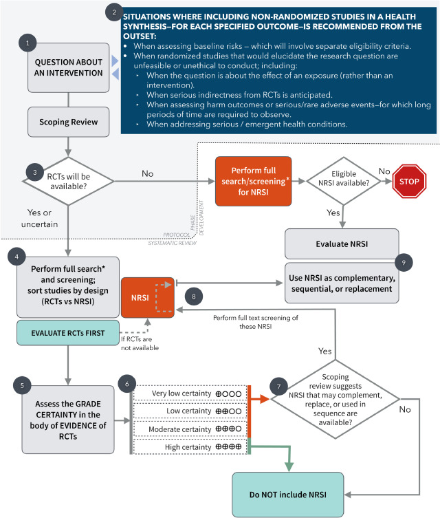

Diagrama de flujo que representa el proceso de realización de una revisión sistemática sobre una intervención de salud considerando el papel de los estudios aleatorios y no aleatorios.

Y lo que podría resultar más util sería triangular la evidencia para determinar efectos potencialmente causales (aunque ningun estudio pueda cumplir al 100% los supuestos de causalidad)

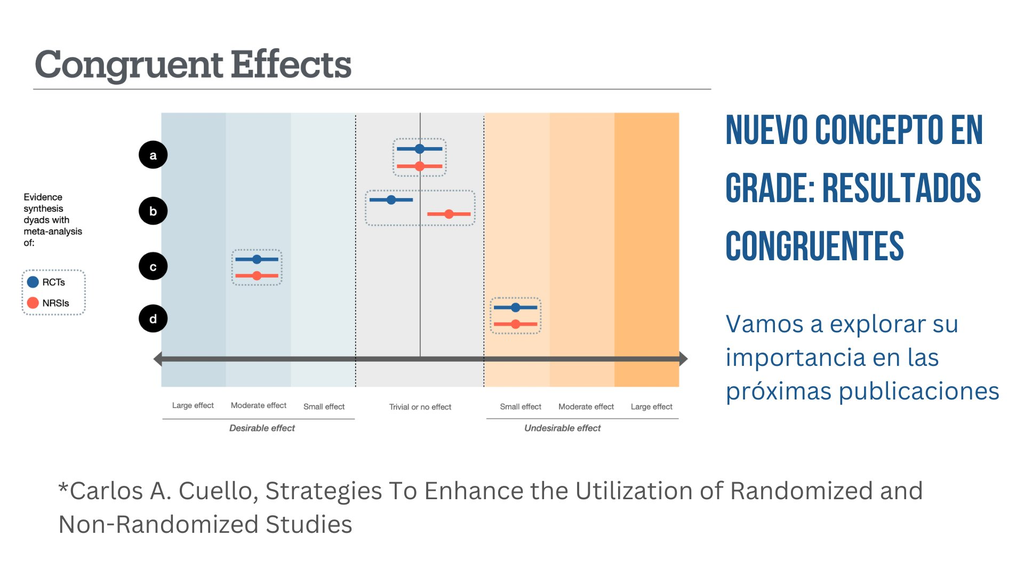

No vamos a complicarnos con tanta teoría pero te recomiendo que leas el siguiente libro [Scott Cunningham. Causal Inference - The Mixtape](https://mixtape.scunning.com/)

Esta semana revisaremos 3 enfoques utilizados en NRCT.

1. Difference-in-Differences
2. Regression Discontinuity
3. Instrumental Variables

# 2 Difference-in-Differences

El diseño de diferencias en diferencias es una estrategia temprana de identificación cuasiexperimental para estimar los efectos causales que precede al experimento aleatorio en aproximadamente ochenta y cinco años. Se ha convertido en el diseño de investigación más popular en las ciencias sociales cuantitativas y, como tal, merece un estudio cuidadoso por parte de investigadores de todo el mundo.

**Ejemplo**

En 1980, Kentucky aumentó el límite de los ingresos semanales cubiertos por la compensación laboral. Queremos saber si esta nueva política provocó que los trabajadores pasaran más tiempo desempleados. Si los beneficios no son lo suficientemente generosos, los trabajadores podrían demandar a las empresas por lesiones en el trabajo, mientras que los beneficios demasiado generosos podrían causar problemas de riesgo moral e inducir a los trabajadores a ser más imprudentes en el trabajo, o a afirmar que las lesiones fuera del trabajo se produjeron mientras se encontraban en el trabajo.

La principal variable de resultado que nos importa es log_duration(en los datos originales como ldurat, pero le cambiamos el nombre para que sea más legible para los humanos), o la duración registrada (en semanas) de los beneficios de compensación laboral. Lo registramos porque la variable está bastante sesgada: la mayoría de las personas están desempleadas durante unas pocas semanas, y algunas están desempleadas durante mucho tiempo. La política fue diseñada para que el aumento del tope no afectara a los trabajadores de bajos ingresos, pero sí a los de altos ingresos, por lo que utilizamos a los trabajadores de bajos ingresos como nuestro grupo de control y a los trabajadores de altos ingresos como nuestro grupo de tratamiento.

Los datos se incluyen en el paquete Wooldridge injury R como conjunto de datos y, si instala el paquete, lo carga con library(wooldridge)y si ejecutas ?injuryen la consola, podrá ver los detalles completos sobre su contenido. Para darle más práctica con la carga de datos desde archivos externos, exporté los datos de lesiones como un archivo CSV (usando write_csv(injury, “injury.csv”)) y los incluí en la carpeta de trabajo

Estas son las columnas principales de las que nos preocuparemos por ahora:

**Cargar y limpiar datos**

```r
library(tidyverse)  # ggplot(), %>%, mutate(), and friends
library(broom)  # Convert models to data frames
library(scales)  # Format numbers with functions like comma(), percent(), and dollar()
library(modelsummary)  # Create side-by-side regression tables

# Load the data.
injury_raw <- read_csv("injury.csv")
```

A continuación, limpiaremos injury_rawun poco los datos para limitarlos a solo observaciones de Kentucky. También cambiaremos el nombre de algunas columnas con nombres extraños:

```r
injury <- injury_raw %>%
  filter(ky == 1) %>%
  # The syntax for rename is `new_name = original_name`
  rename(duration = durat, log_duration = ldurat,
         after_1980 = afchnge)
```

**Análisis exploratorio de datos**

Primero, podemos observar la distribución de las prestaciones por desempleo entre personas con ingresos altos y bajos (nuestros grupos de control y tratamiento):

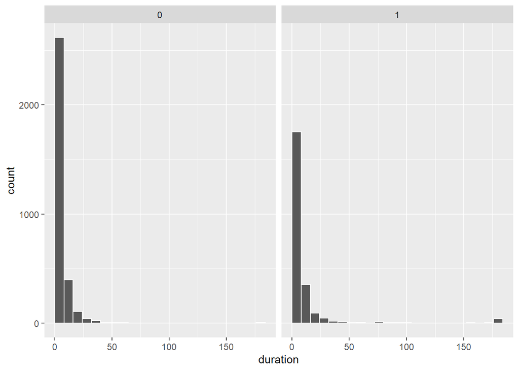

```r
ggplot(data = injury, aes(x = duration)) +
  # binwidth = 8 makes each column represent 2 months (8 weeks)
  # boundary = 0 make it so the 0-8 bar starts at 0 and isn't -4 to 4
  geom_histogram(binwidth = 8, color = "white", boundary = 0) +
  facet_wrap(vars(highearn))
```

La distribución está muy sesgada: la mayoría de las personas en ambos grupos reciben entre 0 y 8 semanas de beneficios (¡y un puñado con más de 180 semanas! ¡Eso es 3,5 años!).

Si utilizamos el registro de duración, podemos obtener una distribución menos sesgada que funciona mejor con modelos de regresión:

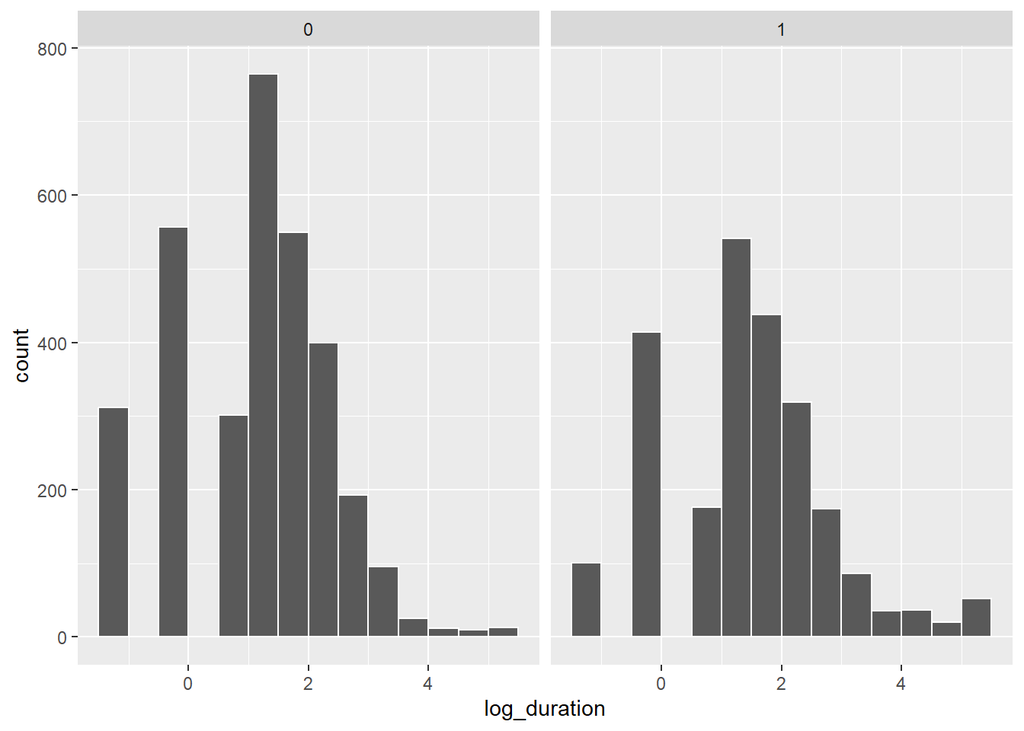

```r
ggplot(data = injury, mapping = aes(x = log_duration)) +
  geom_histogram(binwidth = 0.5, color = "white", boundary = 0) +
  # Uncomment this line if you want to exponentiate the logged values on the
  # x-axis. Instead of showing 1, 2, 3, etc., it'll show e^1, e^2, e^3, etc. and
  # make the labels more human readable
  # scale_x_continuous(labels = trans_format("exp", format = round)) +
  facet_wrap(vars(highearn))
```

También deberíamos comprobar la distribución del desempleo antes y después del cambio de política. Copie/pegue uno de los fragmentos del histograma y cambie las facetas:

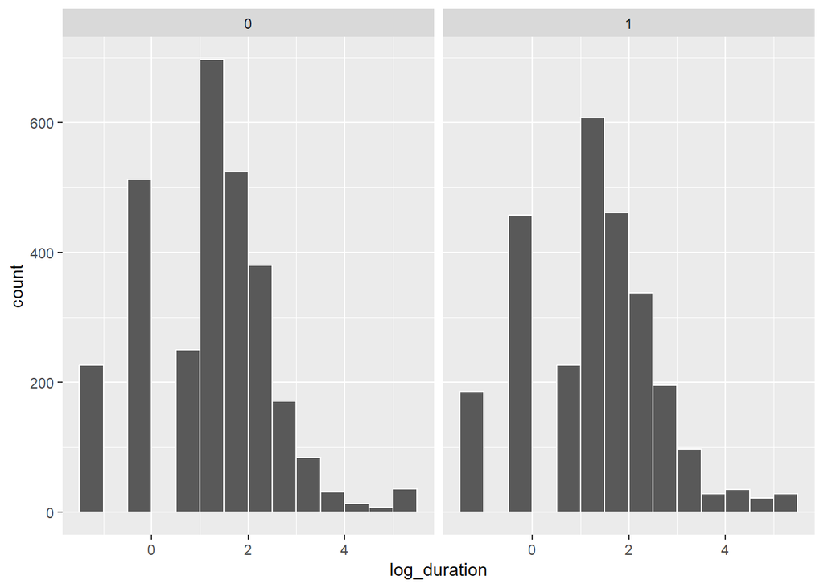

```r
ggplot(data = injury, mapping = aes(x = log_duration)) +
  geom_histogram(binwidth = 0.5, color = "white", boundary = 0) +
  facet_wrap(vars(after_1980))
```

Las distribuciones parecen normales, pero realmente no podemos ver nada diferente entre los grupos de antes/después y de tratamiento/control. Sin embargo, podemos trazar los promedios. Hay algunas maneras diferentes en que podemos hacer esto.

Puede usar una stat_summary()capa para que ggplot calcule estadísticas resumidas como promedios. Aquí simplemente calculamos la media:

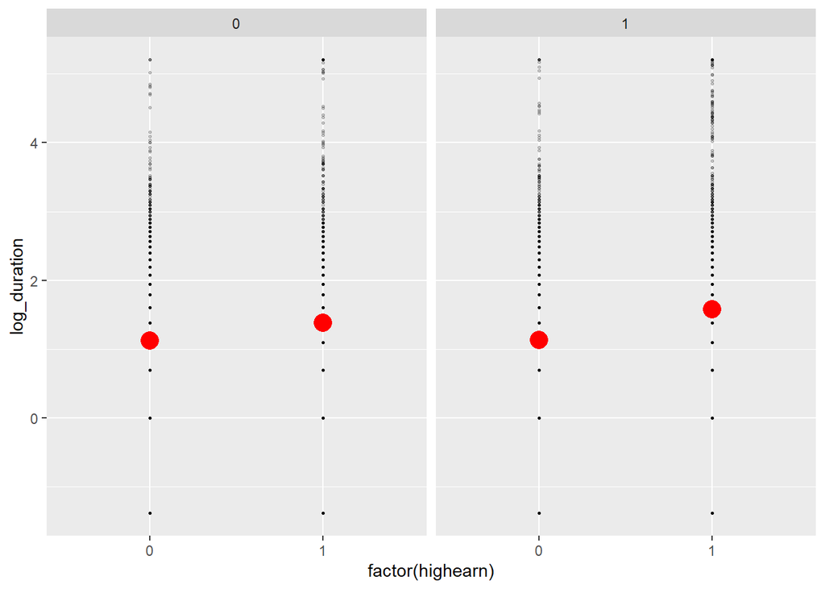

```r
ggplot(injury, aes(x = factor(highearn), y = log_duration)) +
  geom_point(size = 0.5, alpha = 0.2) +
  stat_summary(geom = "point", fun = "mean", size = 5, color = "red") +
  facet_wrap(vars(after_1980))
```

Pero también podemos calcular la media y el intervalo de confianza del 95%:

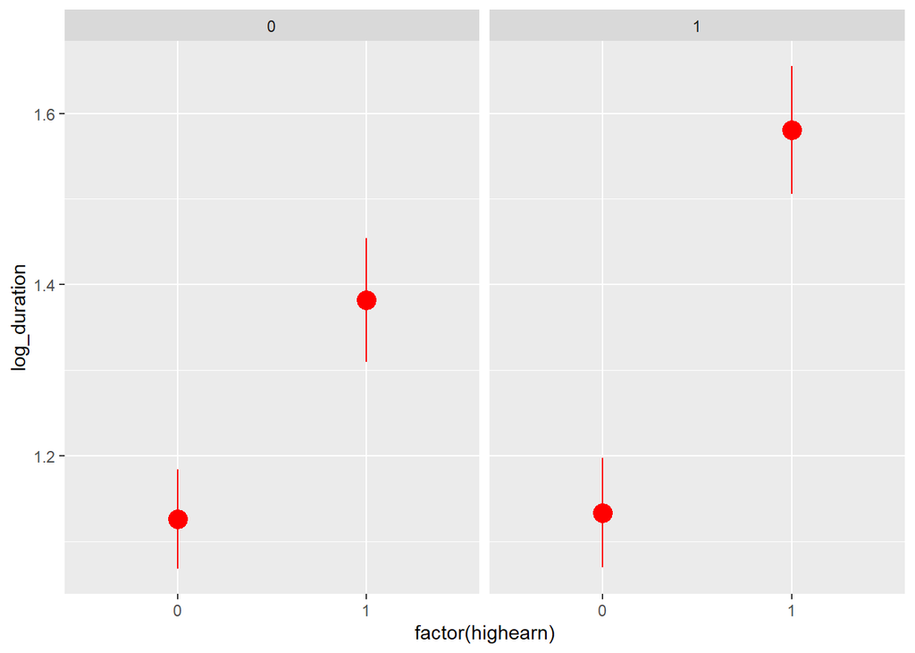

```r
ggplot(injury, aes(x = factor(highearn), y = log_duration)) +
  stat_summary(geom = "pointrange", size = 1, color = "red",
               fun.data = "mean_se", fun.args = list(mult = 1.96)) +
  facet_wrap(vars(after_1980))
```

¡Ya podemos empezar a ver la clásica trama de diferencias entre diferencias! Parece que las personas con mayores ingresos después de 1980 tenían en promedio un desempleo más prolongado.

También podemos usar group_by()y summarize()para descubrir las medias del grupo antes de enviar los datos a ggplot. Prefiero hacer esto porque me da más control sobre los datos que estoy trazando:

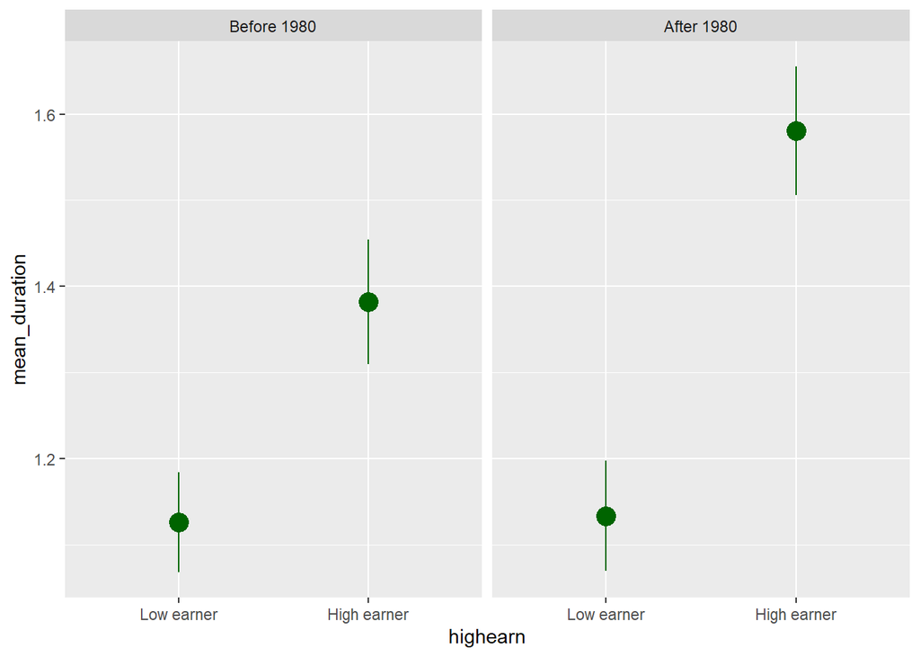

```r
plot_data <- injury %>%
  # Make these categories instead of 0/1 numbers so they look nicer in the plot
  mutate(highearn = factor(highearn, labels = c("Low earner", "High earner")),
         after_1980 = factor(after_1980, labels = c("Before 1980", "After 1980"))) %>%
  group_by(highearn, after_1980) %>%
  summarize(mean_duration = mean(log_duration),
            se_duration = sd(log_duration) / sqrt(n()),
            upper = mean_duration + (1.96 * se_duration),
            lower = mean_duration + (-1.96 * se_duration))

ggplot(plot_data, aes(x = highearn, y = mean_duration)) +
  geom_pointrange(aes(ymin = lower, ymax = upper),
                  color = "darkgreen", size = 1) +
  facet_wrap(vars(after_1980))
```

O bien, trazado en el formato más estándar de diferencia en diferencia:

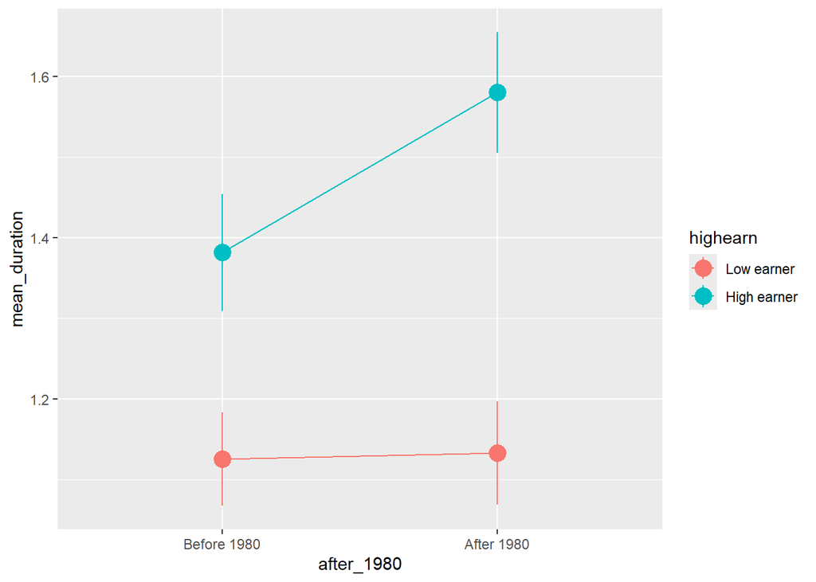

```r
ggplot(plot_data, aes(x = after_1980, y = mean_duration, color = highearn)) +
  geom_pointrange(aes(ymin = lower, ymax = upper), size = 1) +
  # The group = highearn here makes it so the lines go across categories
  geom_line(aes(group = highearn))
```

Comparación entre diferencias a mano

Podemos encontrar esa diferencia exacta completando la tabla 2x2 antes/después del tratamiento/control:

| Suposición | Personas.con.bajos.ingresos | Personas.con.altos.ingresos | X. |
| --- | --- | --- | --- |
| Antes de 1980 | A | C | C-A |
| Después de 1980 | B | D | D - B |
| ∆ | B - A | D - C | (D − C) − (B − A) |

A combination of group_by() and summarize() makes this really easy:

```r
diffs <- injury %>%
  group_by(after_1980, highearn) %>%
  summarize(mean_duration = mean(log_duration),
            # Calculate average with regular duration too, just for fun
            mean_duration_for_humans = mean(duration))
diffs
```

| after_1980 | highearn | mean_duration | mean_duration_for_humans |
| --- | --- | --- | --- |
| 0 | 0 | 1.125615 | 6.271554 |
| 0 | 1 | 1.382094 | 11.176602 |
| 1 | 0 | 1.133273 | 7.037328 |
| 1 | 1 | 1.580352 | 12.893626 |

Podemos sacar cada uno de estos números de la tabla con algunos filter()sy pull():

```r
before_treatment <- diffs %>%
  filter(after_1980 == 0, highearn == 1) %>%
  pull(mean_duration)

before_control <- diffs %>%
  filter(after_1980 == 0, highearn == 0) %>%
  pull(mean_duration)

after_treatment <- diffs %>%
  filter(after_1980 == 1, highearn == 1) %>%
  pull(mean_duration)

after_control <- diffs %>%
  filter(after_1980 == 1, highearn == 0) %>%
  pull(mean_duration)

diff_treatment_before_after <- after_treatment - before_treatment
diff_treatment_before_after
```

```
## [1] 0.1982585
```

```r
## [1] 0.2

diff_control_before_after <- after_control - before_control
diff_control_before_after
```

```
## [1] 0.007657313
```

```r
## [1] 0.0077

diff_diff <- diff_treatment_before_after - diff_control_before_after
diff_diff
```

```
## [1] 0.1906012
```

```r
## [1] 0.19
```

La estimación de diferencia en diferencia es 0,19, lo que significa que el programa provoca un aumento en la duración del desempleo de 0,19 semanas registradas. Sin embargo, registrar semanas no tiene sentido, por lo que tenemos que interpretarlo con porcentajes (es decir, tener altos ingresos después del cambio de política provoca un aumento del 19% en la duración del desempleo).

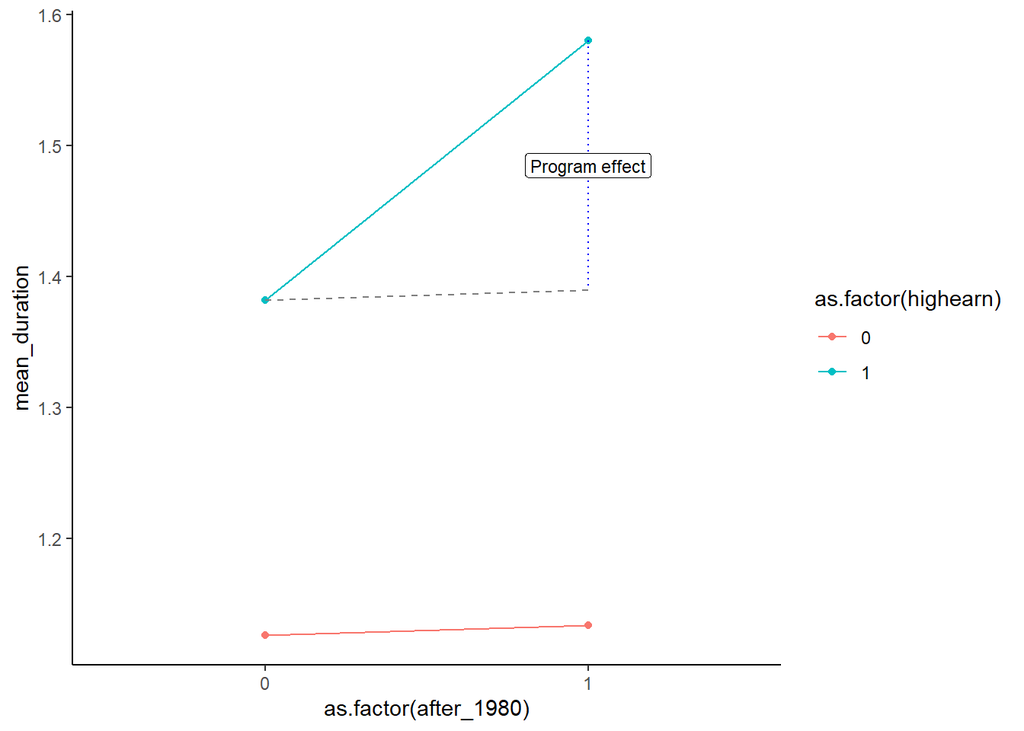

```r
ggplot(diffs, aes(x = as.factor(after_1980),
                  y = mean_duration,
                  color = as.factor(highearn))) +
  geom_point() +
  geom_line(aes(group = as.factor(highearn))) +
  # If you use these lines you'll get some extra annotation lines and
  # labels. The annotate() function lets you put stuff on a ggplot that's not
  # part of a dataset. Normally with geom_line, geom_point, etc., you have to
  # plot data that is in columns. With annotate() you can specify your own x and
  # y values.
  annotate(geom = "segment", x = "0", xend = "1",
           y = before_treatment, yend = after_treatment - diff_diff,
           linetype = "dashed", color = "grey50") +
  annotate(geom = "segment", x = "1", xend = "1",
           y = after_treatment, yend = after_treatment - diff_diff,
           linetype = "dotted", color = "blue") +
  annotate(geom = "label", x = "1", y = after_treatment - (diff_diff / 2),
           label = "Program effect", size = 3)+
theme_classic()
```

## 2.1 Diferencia en diferencia con regresión

Calcular todas las piezas a mano de esta manera es tedioso, ¡así que podemos usar la regresión para hacerlo! Recuerde que debemos incluir variables indicadoras de tratamiento/control y de antes/después, así como la interacción de ambos. Así es como se ve la ecuación matemática:

$$\begin{aligned}
\log(\text{duration}) = &\alpha + \beta \ \text{highearn} + \gamma \
\text{after\_1980} + \\
& \delta \ (\text{highearn} \times \text{after\_1980}) + \epsilon
\end{aligned}$$

El coeficiente $\delta$ es el efecto que al final nos importa: ese es el estimador de diferencia en diferencia.

```r
model_small <- lm(log_duration ~ highearn + after_1980 + highearn * after_1980,
                  data = injury)
tidy(model_small)
```

| term | estimate | std.error | statistic | p.value |
| --- | --- | --- | --- | --- |
| (Intercept) | 1.125615409 | 0.03073683 | 36.6210680 | 1.617404e-263 |
| highearn | 0.256478532 | 0.04744641 | 5.4056464 | 6.723705e-08 |
| after_1980 | 0.007657313 | 0.04471726 | 0.1712384 | 8.640425e-01 |
| highearn:after_1980 | 0.190601201 | 0.06850891 | 2.7821376 | 5.418222e-03 |

El coeficiente para highearn:after_1980es el mismo que encontramos a mano, ¡como debería ser! Es estadísticamente significativo, por lo que podemos estar bastante seguros de que no es 0.

## 2.2 Diferencia en diferencia con regresión + controles

Una ventaja de utilizar la regresión para diferencias en diferencias es que podemos incluir variables de control para ayudar a aislar el efecto. Por ejemplo, tal vez los reclamos presentados por trabajadores de la construcción o la industria manufacturera tiendan a tener una duración más larga que los reclamos presentados por trabajadores de otras industrias. O tal vez quienes reclaman lesiones en la espalda tienden a tener reclamos más largos que quienes reclaman lesiones en la cabeza. También es posible que deseemos controlar la demografía de los trabajadores, como el género, el estado civil y la edad.

Estimemos una versión ampliada del modelo de regresión básico con las siguientes variables adicionales:

- male
- married
- age
- hosp(1 = hospitalizado)
- indust(1 = manufactura, 2 = construcción, 3 = otro)
- injtype(1-8; categorías para diferentes tipos de lesiones)
- lprewage(registro del salario antes de presentar un reclamo)

Importante : industy injtypeestán en el conjunto de datos como números (1-3 y 1-8), pero en realidad son categorías. Tenemos que decirle a R que los trate como categorías (o factores), de lo contrario asumirá que puedes tener un tipo de lesión de 3,46 o algo imposible.

```r
# Convert industry and injury type to categories/factors
injury_fixed <- injury %>%
  mutate(indust = as.factor(indust),
         injtype = as.factor(injtype))
```

```r
model_big <- lm(log_duration ~ highearn + after_1980 + highearn * after_1980 +
                  male + married + age + hosp + indust + injtype + lprewage,
                data = injury_fixed)
tidy(model_big)
```

| term | estimate | std.error | statistic | p.value |
| --- | --- | --- | --- | --- |
| (Intercept) | -1.528201819 | 0.422211753 | -3.619515 | 2.978948e-04 |
| highearn | -0.151780763 | 0.089115617 | -1.703189 | 8.859096e-02 |
| after_1980 | 0.049539510 | 0.041321165 | 1.198889 | 2.306242e-01 |
| male | -0.084288778 | 0.042314659 | -1.991952 | 4.642725e-02 |
| married | 0.056662325 | 0.037304656 | 1.518908 | 1.288451e-01 |
| age | 0.006506964 | 0.001337941 | 4.863415 | 1.186953e-06 |
| hosp | 1.130493166 | 0.037006277 | 30.548687 | 5.199920e-189 |
| indust2 | 0.183864193 | 0.054130748 | 3.396668 | 6.871068e-04 |
| indust3 | 0.163485342 | 0.037852082 | 4.319058 | 1.595428e-05 |
| injtype2 | 0.935467528 | 0.143730662 | 6.508476 | 8.287217e-11 |

[output cut: 8 more lines]

```r
# Extract just the diff-in-diff estimate
diff_diff_controls <- tidy(model_big) %>%
  filter(term == "highearn:after_1980") %>%
  pull(estimate)

diff_diff_controls
```

```
## [1] 0.1687213
```

Después de controlar por una serie de controles demográficos, la estimación de la diferencia entre diferencias es menor (0,17), lo que indica que la política provocó un aumento del 17% en la duración de las semanas desempleadas después de una lesión en el lugar de trabajo. Es más pequeño porque las otras variables independientes ahora explican parte de la variación en log_duration.

# 3 Análisis de series temporales interrumpidas

Esta es una breve introducción al análisis de series temporales interrumpidas.

Los métodos a continuación le mostrarán cómo llevar a cabo una serie temporal interrumpida (STI) utilizando mínimos cuadrados generalizados, teniendo en cuenta la autocorrelación a través de un modelo corARMA (existe otros modelos como ARIMA). Empezaremos con algunos modelos bastante sencillos, para pasar después a algo un poco más complicado, antes de añadir un grupo de control.

Vamos a simular un estudio en el que nos interesa saber si los valores de una cantidad (cantidad.x) han cambiado significativamente en respuesta a algún tipo de intervención. Si te ayuda pensar en una situación del mundo real, imagina que hacemos mediciones semanales de cuántas bacterias se encuentran en las manillas de las puertas de los aseos públicos. Nuestra intervención podría consistir en colocar carteles sobre el lavado de manos en todas las puertas. ¿Podemos afirmar que la colocación de los carteles se correlaciona con una disminución del número de bacterias contadas cada semana?

La base de este análisis es el concepto de contrafactualidad. Haremos algunos modelos para estimar lo que ocurrió (el escenario de los hechos) y lo que esperamos que habría ocurrido (el escenario contrafactual) si nunca hubiéramos colgado los carteles sobre el lavado de manos.

El cambio puede adoptar dos formas

- Un cambio radical inmediatamente después de la intervención

por ejemplo, porque las señales son tan eficaces que de repente todo el mundo empieza a lavarse las manos mucho mejor

- Un cambio de pendiente/tendencia tras la intervención

porque, con el tiempo, la presencia de las señales condiciona que cada vez más personas se laven las manos. Otra posibilidad es que, tras un cambio inicial a la baja, empiece a subir porque la gente empiece a ignorar las señales.

Diferentes escenarios del mundo real pueden o no ser compatibles con los supuestos en los que podrían producirse estos tipos de cambio, así que utilice sus conocimientos para decidir cuáles modelizar.

En cada caso construiremos un conjunto de datos que muestre cada componente del modelo en un formato bastante largo. Es totalmente posible utilizar menos variables y utilizar interacciones (que se muestran más adelante en este documento) para modelar todos los diversos componentes del STI, pero esto es más difícil de entender para el principiante y más difícil de decodificar cuando se trata de conciliar el marco de datos con los coeficientes del modelo que se utilizarán para interpretar qué efectos tuvo la interrupción

## 3.1 ITS no controlada, una intervención

Crearemos un marco de datos ficticio, donde

- time = Un número, el tiempo en semanas de estudio (1 - 100 semanas)
- Intervention = Una indicación binaria de si la Intervención ha tenido lugar en el Momento x
- Post.intervention.time = Un número, el tiempo transcurrido desde la Intervención
- quantity.x = Lo que queremos medir

```r
# create a dummy dataframe
set.seed(123)

# Here the interruption takes place at week 51
df<-tibble::tibble(
  Time = 1:100,
  Intervention = c(rep(0,50),rep(1,50)),
  Post.intervention.time = c(rep(0,50),1:50),
  quantity.x = c(sort(sample(200:300,size = 50,replace = T),decreasing = T)+sample(-20:20,50,replace = T),c(sort(sample(20:170,size = 50,replace = T),decreasing = T)+sample(-40:40,50,replace = T)))
)
```

|  | Time | Intervention | Post.intervention.time | quantity.x |
| --- | --- | --- | --- | --- |
| 1 | 1 | 0 | 0 | 287 |
| 2 | 2 | 0 | 0 | 289 |
| 3 | 3 | 0 | 0 | 287 |
| 4 | 4 | 0 | 0 | 289 |
| 5 | 5 | 0 | 0 | 304 |
| 6 | 6 | 0 | 0 | 297 |
| 7 | 7 | 0 | 0 | 294 |
| 8 | 8 | 0 | 0 | 307 |
| 9 | 9 | 0 | 0 | 289 |
| 10 | 10 | 0 | 0 | 282 |

[output cut: 90 more lines]

En su forma más simple, el modelo ITS tiene el siguiente aspecto

gls(quantity.x ~ Time + Intervention + Post.intervention.time, data = df,method=“ML”)

Utilizando el comando gls del paquete nlme, podemos crear un modelo que describa el cambio en la cantidad.x a lo largo del tiempo

```r
# regresión con comando tradicional
model.a_0 = lm(quantity.x ~ Time + Intervention + Post.intervention.time,
              data = df)
# Show a summary of the model
summary(model.a_0)
```

```
##
## Call:
## lm(formula = quantity.x ~ Time + Intervention + Post.intervention.time,
##     data = df)
##
## Residuals:
##     Min      1Q  Median      3Q     Max
## -33.676 -11.648  -1.037   9.742  48.150
##
## Coefficients:
##                        Estimate Std. Error t value Pr(>|t|)
## (Intercept)            305.4563     5.1409   59.42  < 2e-16 ***
## Time                    -2.0752     0.1755  -11.83  < 2e-16 ***
## Intervention           -38.8972     7.1637   -5.43 4.24e-07 ***
## Post.intervention.time  -0.9877     0.2481   -3.98 0.000134 ***
## ---
## Signif. codes:  0 '***' 0.001 '**' 0.01 '*' 0.05 '.' 0.1 ' ' 1
##
## Residual standard error: 17.9 on 96 degrees of freedom
## Multiple R-squared:  0.9649, Adjusted R-squared:  0.9638
## F-statistic: 880.5 on 3 and 96 DF,  p-value: < 2.2e-16
```

```r
# correremos con gls por facilitarnos la incorporación de otros argumentos pero es lo mismo que una RL

library(nlme)
model.a = gls(quantity.x ~ Time + Intervention + Post.intervention.time,
              data = df,method="ML")

# Show a summary of the model
summary(model.a)
```

```
## Generalized least squares fit by maximum likelihood
##   Model: quantity.x ~ Time + Intervention + Post.intervention.time
##   Data: df
##        AIC      BIC    logLik
##   866.7085 879.7343 -428.3542
##
## Coefficients:
##                            Value Std.Error   t-value p-value
## (Intercept)            305.45633  5.140894  59.41696   0e+00
## Time                    -2.07515  0.175456 -11.82717   0e+00
## Intervention           -38.89719  7.163683  -5.42978   0e+00
## Post.intervention.time  -0.98766  0.248132  -3.98037   1e-04
##
##  Correlation:
##                        (Intr) Time   Intrvn
## Time                   -0.870
## Intervention            0.348 -0.600
## Post.intervention.time  0.615 -0.707 -0.017
##
## Standardized residuals:
##         Min          Q1         Med          Q3         Max
## -1.91972504 -0.66400563 -0.05910527  0.55537520  2.74484741
##
## Residual standard error: 17.5421
## Degrees of freedom: 100 total; 96 residual
```

Estos coeficientes tienen un significado en el mundo real y no están ahí para ser ignorados.

Estos estadísticos nos indican si los cambios que se produjeron en distintos momentos fueron significativos con respecto a lo que hacía la línea antes de la interrupción. Estos valores pueden utilizarse para calcular la diferencia global en la cantidad.x entre los momentos [i] y [ii] mediante esta fórmula

absolute difference = difference(quantity.x[i] , quantity.x[ii])

Pero lo que estaría bien sería calcular el escenario contrafactual en el que no se produjo la intervención y estimar la diferencia entre los valores factuales de la cantidad.x en el momento [i] y los contrafactuales en el mismo momento [i].

Es bueno añadir valores de los modelos al df, por lo que a continuación copiaremos los valores modelados de cantidad.x en el df utilizando el comando predictSE.gls del paquete AICcmodavg.

```r
library(AICcmodavg)
library(tidyverse)

df<-df %>% mutate(
  model.a.predictions = predictSE.gls (model.a, df, se.fit=T)$fit,
  model.a.se = predictSE.gls (model.a, df, se.fit=T)$se
  )
```

|  | Time | Intervention | Post.intervention.time | quantity.x | model.a.predictions | model.a.se |
| --- | --- | --- | --- | --- | --- | --- |
| 1 | 1 | 0 | 0 | 287 | 303.38 | 4.99 |
| 2 | 2 | 0 | 0 | 289 | 301.31 | 4.84 |
| 3 | 3 | 0 | 0 | 287 | 299.23 | 4.69 |
| 4 | 4 | 0 | 0 | 289 | 297.16 | 4.54 |
| 5 | 5 | 0 | 0 | 304 | 295.08 | 4.4 |
| 6 | 6 | 0 | 0 | 297 | 293.01 | 4.26 |
| 7 | 7 | 0 | 0 | 294 | 290.93 | 4.12 |
| 8 | 8 | 0 | 0 | 307 | 288.86 | 3.98 |
| 9 | 9 | 0 | 0 | 289 | 286.78 | 3.85 |
| 10 | 10 | 0 | 0 | 282 | 284.7 | 3.72 |

[output cut: 90 more lines]

Observe que hemos capturado tanto el valor predicho de cantidad.x como el error estándar de la estimación. Lo necesitaremos para mostrar los márgenes de error y dibujar intervalos de confianza en nuestros gráficos.

Hagamos un dibujo en el que mostraremos los puntos de datos brutos y, a continuación, añadamos los datos modelizados como una línea que describa las observaciones objetivas y una cinta que muestre el intervalo de confianza del 95 % en el modelo

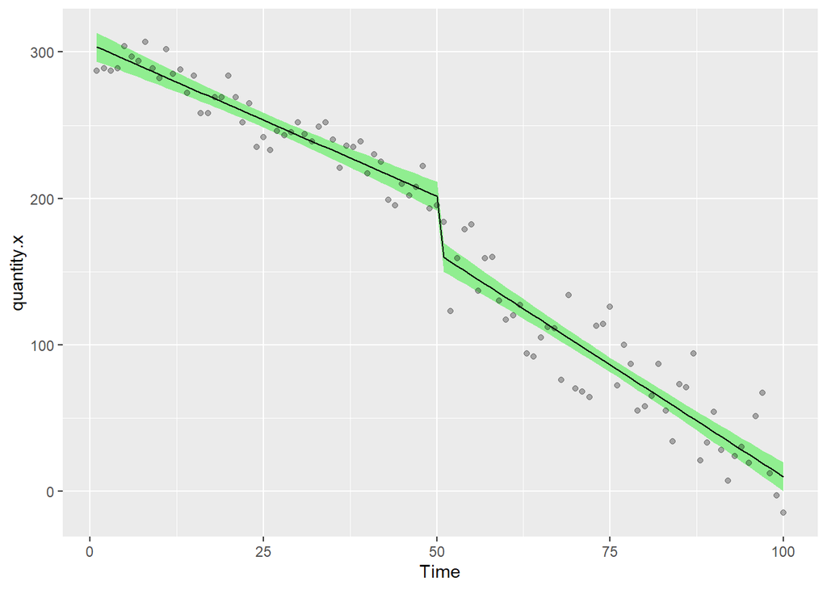

```r
ggplot(df,aes(Time,quantity.x))+
  geom_ribbon(aes(ymin = model.a.predictions - (1.96*model.a.se), ymax = model.a.predictions + (1.96*model.a.se)), fill = "lightgreen")+
  geom_line(aes(Time,model.a.predictions),color="black",lty=1)+
  geom_point(alpha=0.3)
```

Sin embargo, antes de ir más lejos, debemos tener en cuenta la autocorrelación de los datos. gls nos permite añadir estructuras corARMA especificando valores para p (el orden autorregresivo) y q (el orden de la media móvil).

Un modelo gls con una corrección corARMA tiene el siguiente aspecto

gls(quantity.x ~ Time + Intervention + Post.intervention.time, data = df,correlation= corARMA(p=1, q=1, form = ~ Time),method=“ML”)

pero la cuestión crítica es cómo elegir los valores correctos de p y q. Hay mucha información sobre esto en Internet, así que lea atentamente porque es importante. Tanto si entiendes exactamente de qué va todo esto como si no, tendrás que tomar medidas para minimizar el problema empíricamente. Lo que hago aquí es aplicar diferentes valores de p y q al modelo gls, capturando el valor del Criterio de Información de Akaike (AIC) para cada modelo. La combinación de valores de p y q que arroje el menor valor de AIC es la que mejor se ajusta a nuestro modelo.

Siendo realistas, aquí hay cierto margen para los sesgos humanos. Es difícil definir con exactitud las cifras adecuadas para este análisis. Yo recomendaría una amplia gama de valores porque a veces las autocorrelaciones pueden ser bastante retardadas.